# Assignment IV

Troy Zhongyi Zhang

February 27, 2019

> Please submit your answers by 5.59 pm Monday March 4, 2019

## Question 1: Prediction using Logistic Regression

We are going to perform perdiction on a voting dataset (files->assignments->assignment_4). The dataset contains the party affliation of 435 congressional members along with voting record on 16 issues that were put to vote in a single year. The party affliation is indicated as a binary variable as a 1 if the congress-person was a member of the ‘A’ party and 0 otherwise. The vote is indicated as 1 (if the member voted yes) and 0 (if ithe member voted no).

1. You will notice that the class-split is fairly even in the dataset.

0 : 168 members 1 : 267 members

Using caret, create a rough 80-20 split of the dataset into training and testing. In other words, 80% of the data should comprise the training dataset and 20% of the data should comprise the testing dataset. Ensure that the class membership is even (in other words, the proportion of 1 and 0 in both training and testing should be the approximately the same)

NOTE: Set the seed to 476

```r
# Insert your code below
rm(list=ls())
library(plyr)
library(dplyr)
library(pROC)
library(caret)
library(MASS)
d.1 <- read.csv("~/Desktop/data_votes.csv",header = TRUE)
d.1 <- d.1[complete.cases(d.1),]
d.1 <- d.1 %>%
  filter(party_A != "")
d.1$party_A <- factor(d.1$party_A)
set.seed(476)
train_index <- createDataPartition(d.1$party_A, p = .8, list = FALSE, times = 1)
head(train_index)
```

```
##      Resample1
## [1,]         1
## [2,]         2
## [3,]         3
## [4,]         4
## [5,]         5
## [6,]         8
```

```r
d.train <- d.1[train_index,]
head(d.train)
```

```
##   party_A handicapped_infants water_project_cost_sharing
## 1       1                   1                          0
## 2       1                   1                          0
## 3       1                   1                          0
## 4       1                   1                          0
## 5       1                   1                          0
## 8       1                   0                          0
##   adoption_of_bufget_resolution physician_fee_freeze el_salvador_aid
## 1                             1                    0               0
## 2                             1                    0               0
## 3                             1                    0               0
## 4                             1                    0               0
## 5                             1                    0               0
## 8                             1                    0               0
##   religious_group_in_schools anti_satellite_test_ban nicaragua_aid
```

[output cut: 20 more lines]

```r
d.test <- d.1[-train_index,]
summary(as.factor(d.train$party_A))
```

```
##   0   1
## 135 214
```

```r
summary(as.factor(d.test$party_A))
```

```
##  0  1
## 33 53
```

2. Perform a logistic regression (using glm) on the training dataset and perform a prediction on the test dataset.

```r
# Insert your code below
m.log <- glm(party_A~., data = d.train, family = "binomial")
d.test$pred_party_A <- predict.glm(m.log,
newdata = d.test,
type = "response")
m.log
```

```
##
## Call:  glm(formula = party_A ~ ., family = "binomial", data = d.train)
##
## Coefficients:
##                   (Intercept)            handicapped_infants
##                       -1.3665                         0.8535
##    water_project_cost_sharing  adoption_of_bufget_resolution
##                        2.2776                         5.2391
##          physician_fee_freeze                el_salvador_aid
##                      -10.3548                        -0.1973
##    religious_group_in_schools        anti_satellite_test_ban
##                        0.5167                         0.1184
##                 nicaragua_aid                     mx_missile
##                       -0.5569                         3.1484
##                   immigration              syn_coorp_cutback
##                       -2.0112                         5.7163
##            education_spending         superfund_right_to_sue
##                       -0.5277                         1.8777
##                         crime              duty_free_exports
##                        1.1626                         2.3547
##                 export_act_sa
##                       -2.2970
##
## Degrees of Freedom: 348 Total (i.e. Null);  332 Residual
## Null Deviance:       465.8
## Residual Deviance: 39.82     AIC: 73.82
```

3. Fill the confusion matrix below using your predictions. Consider outcome 1 as being “positive” and a probability cutoff of 0.5 (i.e. if probability >= 0.5, assign the label 1).

```r
# Insert your code below

d.test$pred_party_A <- ifelse(d.test$pred_party_A >= 0.5, 1, 0)
tp <- d.test %>%
  filter(party_A == 1 & pred_party_A == 1) %>% nrow()
tn <- d.test %>%
  filter(party_A == 0 & pred_party_A == 0) %>% nrow()
fp <- d.test %>%
  filter(party_A == 0 & pred_party_A == 1) %>% nrow()
fn <- d.test %>%
  filter(party_A == 1 & pred_party_A == 0) %>% nrow()
sprintf("They should be %i, %i, %i, %i", tp,fp,fn,tn)
```

```
## [1] "They should be 50, 0, 3, 33"
```

| Table | Actual_positive | Actual_negative |
| --- | --- | --- |
| Pred_positive | 50 | 0 |
| Pred_negative | 3 | 33 |

4. Calculate the following: Sensitivity, Specificity, Positive Predictive Value, Negative Predictive Value, False Positive Rate, and Accuracy.

```
## [1] 0.9433962
```

```
## [1] "Sensitivity is 0.94339623"
```

```
## [1] 1
```

```
## [1] "Specificity is 1.00000000"
```

```
## [1] 1
```

```
## [1] "Positive predictive value is 1.00000000"
```

```
## [1] 0.9166667
```

```
## [1] "Negative predictive value is 0.91666667"
```

```
## [1] 0
```

```
## [1] "False positive rate is 0.00000000"
```

```
## [1] 0.9651163
```

```
## [1] "Accuracy is 0.96511628"
```

5. Calculate AUC (with 95% CI) using predicted probabilities

```r
# Insert code below
library(pROC)
d.5 <- read.csv("~/Desktop/data_votes.csv",header = TRUE)
d.5 <- d.5[complete.cases(d.5),]
d.5 <- d.5 %>%
  filter(party_A != "")
d.5$party_A <- factor(d.5$party_A)
set.seed(476)
train_index5 <- createDataPartition(d.5$party_A, p = .8, list = FALSE, times = 1)
head(train_index5)
```

```
##      Resample1
## [1,]         1
## [2,]         2
## [3,]         3
## [4,]         4
## [5,]         5
## [6,]         8
```

```r
d.train5 <- d.5[train_index5,]
head(d.train5)
```

```
##   party_A handicapped_infants water_project_cost_sharing
## 1       1                   1                          0
## 2       1                   1                          0
## 3       1                   1                          0
## 4       1                   1                          0
## 5       1                   1                          0
## 8       1                   0                          0
##   adoption_of_bufget_resolution physician_fee_freeze el_salvador_aid
## 1                             1                    0               0
## 2                             1                    0               0
## 3                             1                    0               0
## 4                             1                    0               0
## 5                             1                    0               0
## 8                             1                    0               0
##   religious_group_in_schools anti_satellite_test_ban nicaragua_aid
```

[output cut: 20 more lines]

```r
d.test5 <- d.5[-train_index5,]

d.test5$pred_party_A5 <- predict.glm(m.log,newdata = d.test5, type = "response")
# Create a prediction object
pred5 <- roc(response = d.test5$party_A, predictor = d.test5$pred_party_A, direction = "<")
# Get AUC performance
auc_perf5 <- auc(pred5)
cat("AUC: ", auc_perf5, "\n")
```

```
## AUC:  0.9914237
```

```r
# Get 95% CI
ci_auc_perf5 <- ci.auc(pred5)
cat("95% CI: ", ci_auc_perf5, "\n")
```

```
## 95% CI:  0.9761996 0.9914237 1
```

```r
auc5 <- cat("AUC: ", auc_perf5, "\n")
```

```
## AUC:  0.9914237
```

## Question 2: Cross-validation

Write a program that will perform 3-fold cross-validation (using the caret package) on the above train dataset. Calculate AUC (with 95% CI) on the test dataset.

NOTE : Set your seed as 156

```r
# Insert code here

library(caret)
library(e1071)
d.1<-read.csv("~/Desktop/data_votes.csv")
d.1<- d.1[complete.cases(d.1),]
d.1 <- d.1%>%
  filter(party_A!="")
d.1 <- d.1 %>%
   mutate(party_A = as.factor(party_A),handicapped_infants = as.factor(handicapped_infants), water_project_cost_sharing = as.factor(water_project_cost_sharing), adoption_of_bufget_resolution = as.factor(adoption_of_bufget_resolution),physician_fee_freeze = as.factor(physician_fee_freeze), el_salvador_aid = as.factor(el_salvador_aid),religious_group_in_schools = as.factor(religious_group_in_schools),anti_satellite_test_ban = as.factor (anti_satellite_test_ban), nicaragua_aid = as.factor(nicaragua_aid), mx_missile = as.factor(mx_missile), immigration=as.factor(immigration), syn_coorp_cutback = as.factor(syn_coorp_cutback), education_spending = as.factor(education_spending), superfund_right_to_sue = as.factor(superfund_right_to_sue), crime = as.factor(crime), duty_free_exports = as.factor(duty_free_exports), export_act_sa = as.factor(export_act_sa))
d.1$party_A <- factor(d.1$party_A)
set.seed(156)
train_index2 <- createDataPartition(d.1$party_A, p = .8, list = FALSE, times = 1)
head(train_index2)
```

```
##      Resample1
## [1,]         1
## [2,]         2
## [3,]         3
## [4,]         5
## [5,]         6
## [6,]         7
```

```r
d.train2 <- d.1[train_index2,]
d.test2 <- d.1[-train_index2,]

#party_folds <- createFolds(d.train2$party_A, k =3, list = TRUE)
#head(party_folds$Fold01)
#head(party_folds$Fold02)

# 3-fold CV
training_params <- trainControl(method="cv",number = 3)
m.train.glm <- train(as.factor(party_A) ~ ., data = d.train, method = "glm", trControl = training_params)
m.train.glm
```

```
## Generalized Linear Model
##
## 349 samples
##  16 predictor
##   2 classes: '0', '1'
##
## No pre-processing
## Resampling: Cross-Validated (3 fold)
## Summary of sample sizes: 232, 233, 233
## Resampling results:
##
##   Accuracy   Kappa
##   0.9456233  0.8850428
```

```r
summary(m.train.glm)
```

```
##
## Call:
## NULL
##
## Deviance Residuals:
##      Min        1Q    Median        3Q       Max
## -2.50447  -0.00922   0.00227   0.03336   2.53536
##
## Coefficients:
##                               Estimate Std. Error z value Pr(>|z|)
## (Intercept)                    -1.3665     1.4389  -0.950 0.342271
## handicapped_infants             0.8535     1.1789   0.724 0.469056
## water_project_cost_sharing      2.2776     1.3538   1.682 0.092494 .
## adoption_of_bufget_resolution   5.2391     1.4789   3.543 0.000396 ***
## physician_fee_freeze          -10.3548     2.4225  -4.274 1.92e-05 ***
## el_salvador_aid                -0.1973     2.4615  -0.080 0.936124
## religious_group_in_schools      0.5167     1.5101   0.342 0.732219
## anti_satellite_test_ban         0.1184     1.6612   0.071 0.943166
## nicaragua_aid                  -0.5569     2.0170  -0.276 0.782487
## mx_missile                      3.1484     1.5380   2.047 0.040644 *
## immigration                    -2.0112     1.2426  -1.619 0.105554
## syn_coorp_cutback               5.7163     1.8020   3.172 0.001513 **
## education_spending             -0.5277     1.1996  -0.440 0.660053
## superfund_right_to_sue          1.8777     1.5557   1.207 0.227447
## crime                           1.1626     1.2597   0.923 0.356066
## duty_free_exports               2.3547     1.3106   1.797 0.072402 .
## export_act_sa                  -2.2970     1.4037  -1.636 0.101745
## ---
## Signif. codes:  0 '***' 0.001 '**' 0.01 '*' 0.05 '.' 0.1 ' ' 1
##
## (Dispersion parameter for binomial family taken to be 1)
##
##     Null deviance: 465.778  on 348  degrees of freedom
## Residual deviance:  39.825  on 332  degrees of freedom
## AIC: 73.825
##
## Number of Fisher Scoring iterations: 9
```

```r
yhat_glm <- predict(m.train.glm, newdata = d.test, type = "prob")

# Create a prediction object
glm.pred <- roc(predictor = yhat_glm[,2],
response = d.test$party_A, direction = "<")
# Get performance
auc.perf <- auc(glm.pred)
ci.auc.perf <- ci.auc(glm.pred)
auc.perf
```

```
## Area under the curve: 0.9914
```

```r
ci.auc.perf
```

```
## 95% CI: 0.9762-1 (DeLong)
```

```r
cat("AUC: ", auc.perf, "\n")
```

```
## AUC:  0.9914237
```

```r
cat("95% CI: ", ci.auc.perf, "\n")
```

```
## 95% CI:  0.9761996 0.9914237 1
```

## Question 3: Hierarchical clustering

We are going to use the USArrests dataset. Load this using the following command

```r
d.in <- data.frame(USArrests)
head(d.in)
```

```
##            Murder Assault UrbanPop Rape
## Alabama      13.2     236       58 21.2
## Alaska       10.0     263       48 44.5
## Arizona       8.1     294       80 31.0
## Arkansas      8.8     190       50 19.5
## California    9.0     276       91 40.6
## Colorado      7.9     204       78 38.7
```

1. Perform hierarchical clustering using average linkage and Euclidean distance. Write the code and show the plots below.

Ans.

```r
# Insert code here

#library(dendextend)
#install.packages("viridisLite")
#if (!require("devtools"))install.packages("devtools")
#devtools::install_github("sjmgarnier/viridis")
#install.packages("dendextend")
#install.packages("mvtnorm")
library(mvtnorm)
library(dendextend)
dist_in <- dist(d.in, method = "euclidean")
temp_matrix <- as.matrix(dist_in)
print(temp_matrix[1:6, 1:6])
```

```
##             Alabama   Alaska   Arizona  Arkansas California Colorado
## Alabama     0.00000 37.17701  63.00833  46.92814   55.52477 41.93256
## Alaska     37.17701  0.00000  46.59249  77.19741   45.10222 66.47594
## Arizona    63.00833 46.59249   0.00000 108.85192   23.19418 90.35115
## Arkansas   46.92814 77.19741 108.85192   0.00000   97.58202 36.73486
## California 55.52477 45.10222  23.19418  97.58202    0.00000 73.19713
## Colorado   41.93256 66.47594  90.35115  36.73486   73.19713  0.00000
```

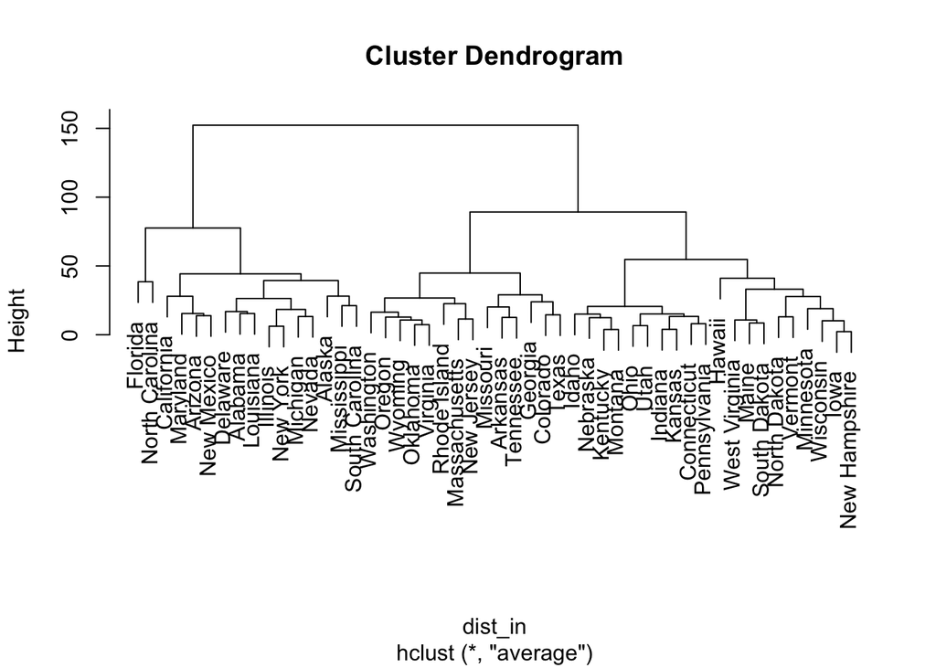

```r
h_in <- hclust(dist_in, method="average")
plot(h_in)
```

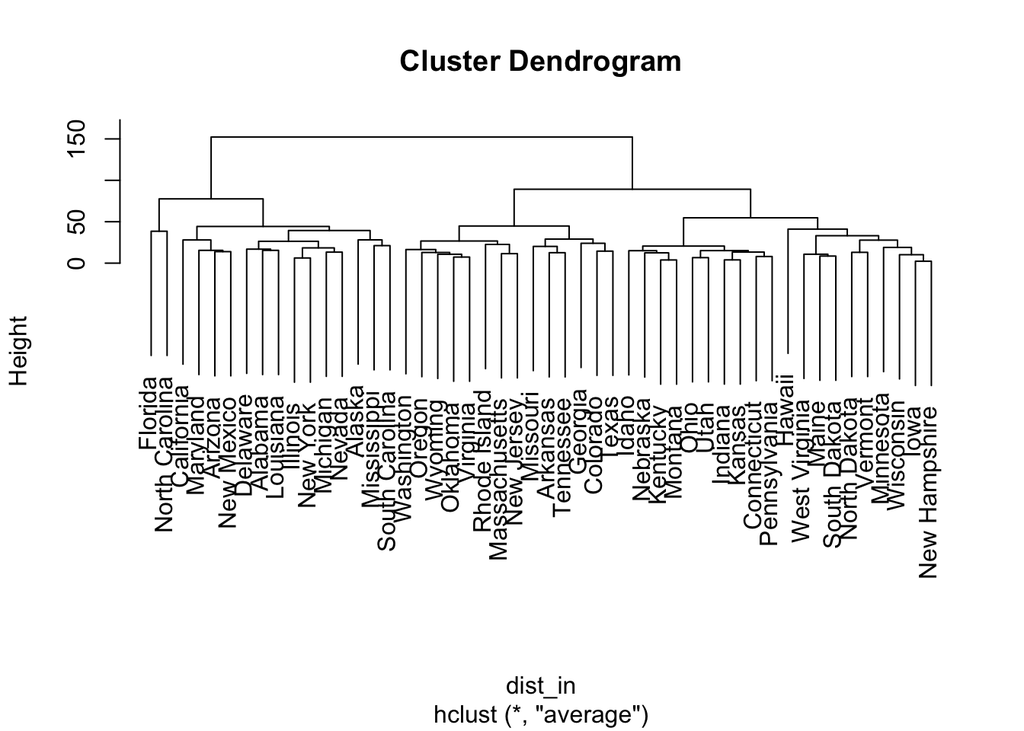

```r
plot(h_in,hang=1)
```

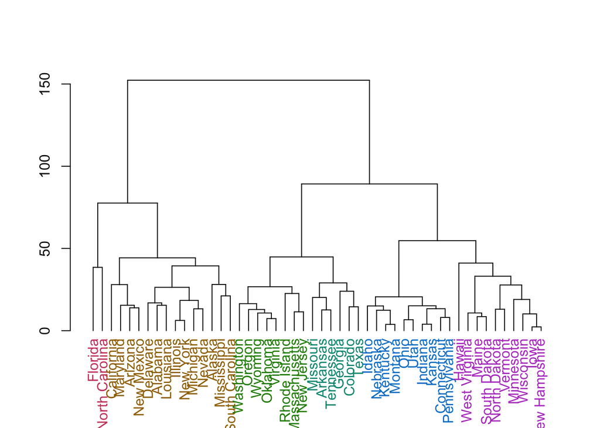

```r
dend = as.dendrogram(h_in)
dend <- color_labels(dend, k=6)
plot(dend)
```

```r
# Insert code here
dist_in <- as.data.frame(scale(dist_in))
dist_in <- dist(d.in, method = "euclidean")

temp_matrix <- as.matrix(dist_in)
print(temp_matrix[1:6, 1:6])
```

```
##             Alabama   Alaska   Arizona  Arkansas California Colorado
## Alabama     0.00000 37.17701  63.00833  46.92814   55.52477 41.93256
## Alaska     37.17701  0.00000  46.59249  77.19741   45.10222 66.47594
## Arizona    63.00833 46.59249   0.00000 108.85192   23.19418 90.35115
## Arkansas   46.92814 77.19741 108.85192   0.00000   97.58202 36.73486
## California 55.52477 45.10222  23.19418  97.58202    0.00000 73.19713
## Colorado   41.93256 66.47594  90.35115  36.73486   73.19713  0.00000
```

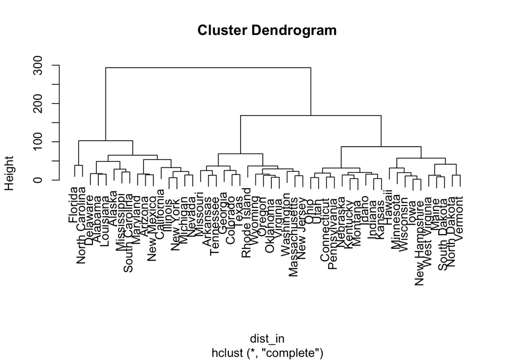

```r
h_in2 <- hclust(dist_in, method="complete")
plot(h_in2)
```

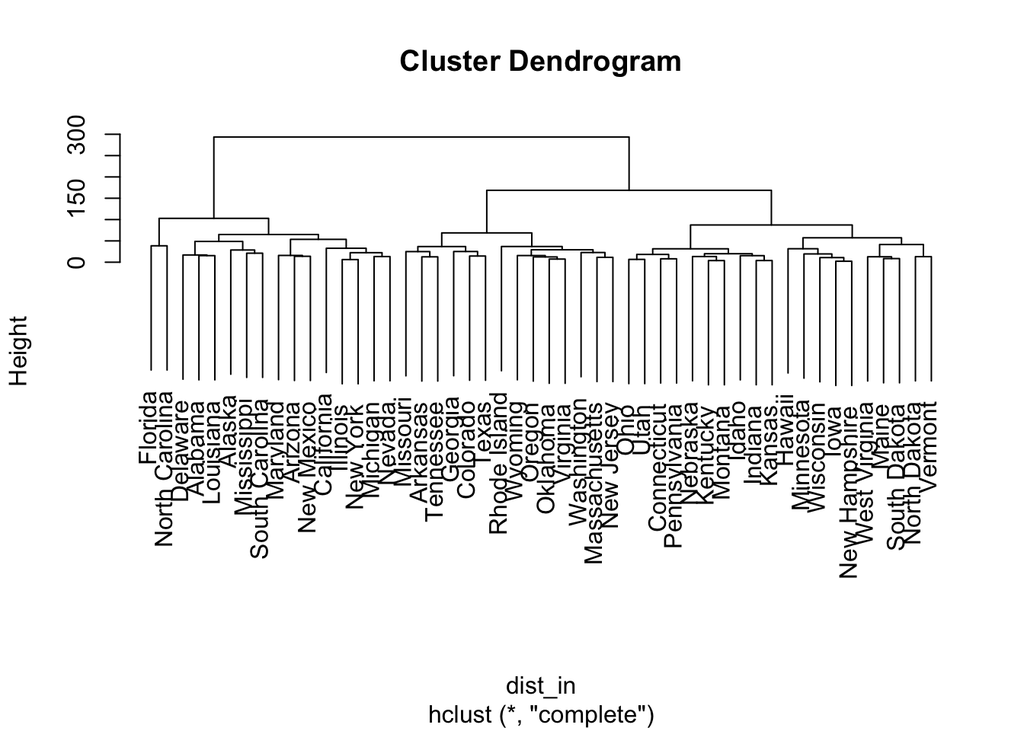

```r
plot(h_in2,hang=1)
```

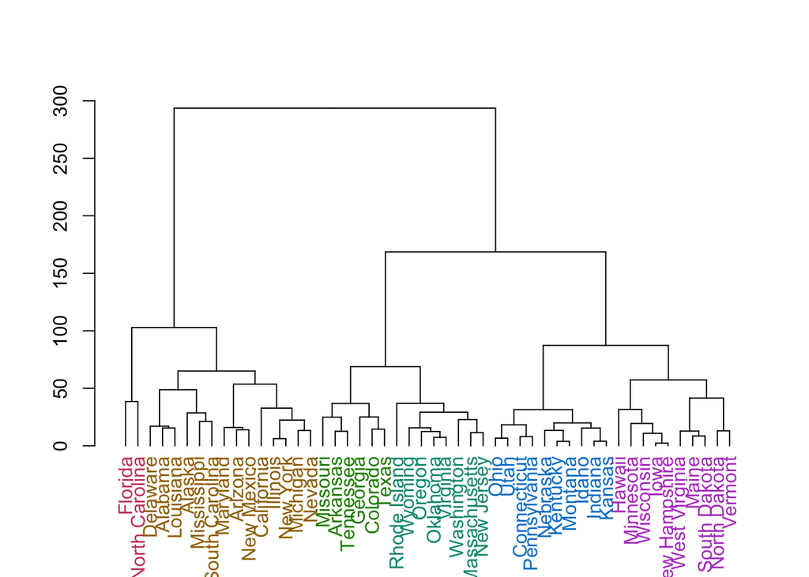

```r
dend2 = as.dendrogram(h_in2)
dend2 <- color_labels(dend2, k=6)
plot(dend2)
```

## Question 4: K-means clustering

Download the dataset kmeans_data.csv (Files->Assignments->Assignment_4). The dataset contains randomly generated 100 observations of 2 variables, viz., X1 and X2

1. Plot X1 vs. X2 (i.e. X1 on the x-axis) as a scatter-plot. Write the code below.

[figure not shown]

```r
# Insert code\
library(ggplot2)
d.2 <- read.csv("~/Desktop/kmeans_data.csv", header = TRUE)
plot(d.2$X2,d.2$X1,data = d.2,main="x1 vs. x2",xlab="X1", ylab="X2")
```

2. Perform a k-means clustering with $K$ = 3. Overlap the cluster labels on the scatter plot.

```r
# Insert code
#Zhongyi's Assignment
kmeans_in <- kmeans(d.2,centers=3)
names(kmeans_in)
```

```
## [1] "cluster"      "centers"      "totss"        "withinss"
## [5] "tot.withinss" "betweenss"    "size"         "iter"
## [9] "ifault"
```

```r
kmeans_in$cluster
```

```
##   [1] 1 1 1 1 1 1 1 1 1 1 1 1 1 1 1 1 1 1 1 1 1 1 1 1 1 3 3 3 3 3 3 3 3 3 3
##  [36] 3 3 3 3 3 3 3 3 3 3 3 3 3 3 3 3 3 3 3 3 3 3 3 3 3 3 3 3 3 3 3 3 3 3 3
##  [71] 3 3 3 3 2 2 2 2 2 2 2 2 2 2 2 2 2 2 2 2 2 2 2 2 2 2 2 2 2 2
```

```r
kmeans_in$centers
```

```
##           X1          X2
## 1  5.3339737 -2.65905457
## 2 -5.1798330  2.67365854
## 3 -0.1376224  0.05883076
```

[figure not shown]

```r
plot(d.2$X1, d.2$x2,col=kmeans_in$cluster,xlab = "X1", ylab ="X2",main = "k-means plot for $k$ = 3",pch=19,cex=2)
points(kmeans_in$centers,col=1:3,pch=3,cex=3,lwd=3)
```

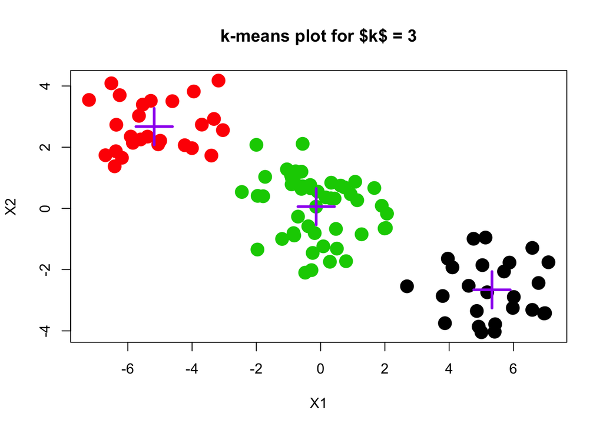

```r
KMeans_in <- kmeans(d.2,centers=3)
plot(d.2$X1, d.2$X2,col=kmeans_in$cluster,xlab = "X1", ylab ="X2",main = "k-means plot for $k$ = 3",pch=19,cex=2)
points(kmeans_in$centers,pch=3,cex=4,lwd=3, col="purple")
```

```r
print(kmeans_in$betweenss)
```

```
## [1] 1771.599
```

```r
print(kmeans_in$tot.withinss)
```

```
## [1] 219.1554
```